Bruno de Abreu Machado

# Doar Sangue salva vidas

Analise e predição de doadores de sangue

Mar 29, 2020 • 6 min read

jupyter

- Explorando os dados
  - O dataset
  - Descrição das Variáveis:
  - Explorando
  - Relações
  - Residuais
  - Reg
  - Distribuição Multivariada
  - Pairplot
  - Feature Eng
- Save DataFrame to picckle
- Modelagem
  - GaussianNB - acc 70%
  - Logistic Regression - acc 74%
  - SVM - acc 73%
  - Tree - acc 67%

[figure not shown]

Doar sangue salva vidas, isso é divulgado nas mídias sociais, além de ser utilizado para procedimentos e intervenções médicas é utilizado no tratamento de diversas doenças crônicas.

Constantemente os bancos de sangue estão com estoques abaixo da normalidade, principalmente durantes os meses de férias. Com isso Ministério da Saúde reforça periodicamente a importância de adotar uma cultura solidária da doação regular e espontânea de sangue. Mas na prática poucos buscam os postos de doação de forma voluntária, normalmente é incentivado quando um parente ou amigo solicita doação.

Como a doação é voluntárias é difícil para os centros de hemoterapia e hospitais saberem quando um doador irá retornar para doar sangue

## Explorando os dados

### O dataset

Este conjunto de dados foi doado pelo *Blood Transfusion Service Center* na cidade de *Hsin-Chu City* em **Taiwan** em 2008, infelizmente não encontrei nenhuma fonte de dados abertos com algo similar.

Este dataset é disponibilizado pelo [UCI-Blood Transfusion Service Center Data Set](https://archive.ics.uci.edu/ml/datasets/Blood+Transfusion+Service+Center) e 2019 *drivendata.org* promoveu uma competição com o tema [Warm Up: Predict Blood Donations](https://www.drivendata.org/competitions/6/countable-care-modeling-womens-health-care-decisions/)

```python
#collapse-hide
import pandas as pd
```

```python
#collapse-hide
cols = ['rec', 'frec', 'total', 'time', 'target']

df = pd.read_csv('data/transfusion.data', names=cols, header=0)

df.head()
```

|  | rec | frec | total | time | target |
| --- | --- | --- | --- | --- | --- |
| 0 | 2 | 50 | 12500 | 98 | 1 |
| 1 | 0 | 13 | 3250 | 28 | 1 |
| 2 | 1 | 16 | 4000 | 35 | 1 |
| 3 | 2 | 20 | 5000 | 45 | 1 |
| 4 | 1 | 24 | 6000 | 77 | 0 |

```python
df.info()
```

```
<class 'pandas.core.frame.DataFrame'>
RangeIndex: 748 entries, 0 to 747
Data columns (total 5 columns):
rec       748 non-null int64
frec      748 non-null int64
total     748 non-null int64
time      748 non-null int64
target    748 non-null int64
dtypes: int64(5)
memory usage: 29.3 KB
```

### Descrição das Variáveis:

- rec : meses desde a última doação
- fre: total número de doações
- total : Total de sangue doado
- time : meses desde primeira doação
- target : Informação se foi doado ou não

### Explorando

```python
df.head()
```

|  | rec | frec | total | time | target |
| --- | --- | --- | --- | --- | --- |
| 0 | 2 | 50 | 12500 | 98 | 1 |
| 1 | 0 | 13 | 3250 | 28 | 1 |
| 2 | 1 | 16 | 4000 | 35 | 1 |
| 3 | 2 | 20 | 5000 | 45 | 1 |
| 4 | 1 | 24 | 6000 | 77 | 0 |

```python
#collapse-hide
df.total.value_counts()
```

```
250      158
500      112
750       87
1000      62
1250      62
1500      52
1750      43
2000      31
2250      24
2750      22
2500      14
3000      14
4000      13
3500      13
3250       9
```

[output cut: 19 more lines]

```python
#collapse-show
df.describe()
```

|  | rec | frec | total | time | target |
| --- | --- | --- | --- | --- | --- |
| count | 748.000000 | 748.000000 | 748.000000 | 748.000000 | 748.000000 |
| mean | 9.506684 | 5.514706 | 1378.676471 | 34.282086 | 0.237968 |
| std | 8.095396 | 5.839307 | 1459.826781 | 24.376714 | 0.426124 |
| min | 0.000000 | 1.000000 | 250.000000 | 2.000000 | 0.000000 |
| 25% | 2.750000 | 2.000000 | 500.000000 | 16.000000 | 0.000000 |
| 50% | 7.000000 | 4.000000 | 1000.000000 | 28.000000 | 0.000000 |
| 75% | 14.000000 | 7.000000 | 1750.000000 | 50.000000 | 0.000000 |
| max | 74.000000 | 50.000000 | 12500.000000 | 98.000000 | 1.000000 |

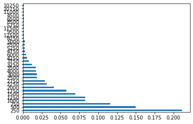

```python
#collapse-show
df.total.value_counts(normalize=True).plot(kind='barh')
plt.show()
```

```python
#collapse-hide
df.groupby('frec')['total'].mean()
```

```
frec
1       250
2       500
3       750
4      1000
5      1250
6      1500
7      1750
8      2000
9      2250
10     2500
11     2750
12     3000
13     3250
14     3500
```

[output cut: 20 more lines]

```python
#collapse-hide
import matplotlib.pyplot as plt
import seaborn as sns
```

### Relações

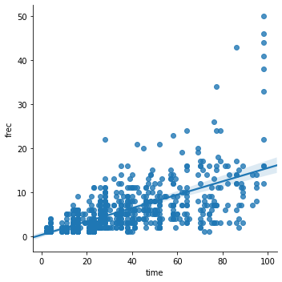

```python
#collapse-show
sns.lmplot(x='time', y='frec', data=df)
```

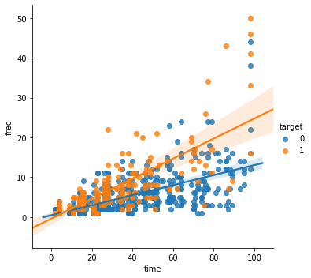

```python
#collapse-show
sns.lmplot(x='time', y='frec', hue='target', data=df)
```

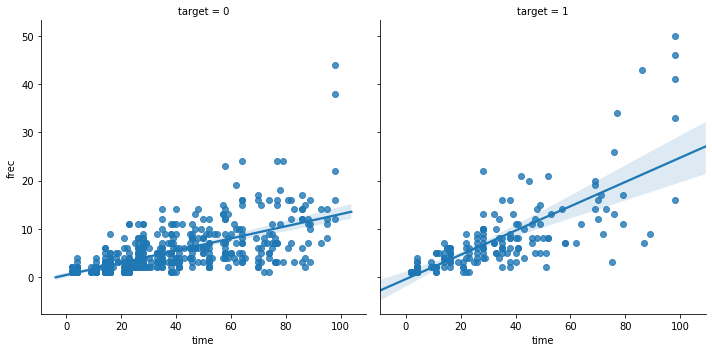

```python
#collapse-show
sns.lmplot(x='time', y='frec', col='target', data=df)
```

### Residuais

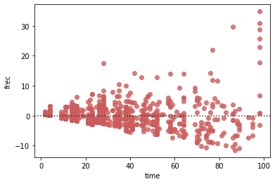

```python
#collapse-hide
sns.residplot(x='time', y='frec', data=df, color='indianred')
```

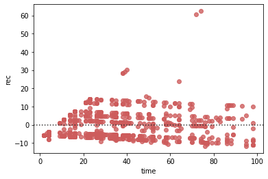

```python
#collapse-hide
sns.residplot(x='time', y='rec', data=df, color='indianred')
```

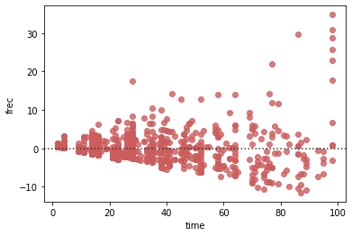

```python
#collapse-hide
sns.residplot(x='time', y='frec', data=df, color='indianred')
```

### Reg

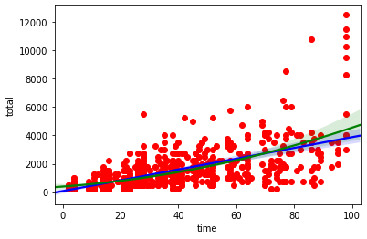

```python
#collapse-show
plt.scatter(df.time, df.total,
            label='data', color='red', marker='o')

sns.regplot(x='time', y='total', data=df,
            color='blue', scatter=None, label='1st Order')

sns.regplot(x='time', y='total', data=df,
            color='green', order=2 ,scatter=None, label='2nd Order')
```

### Distribuição Multivariada

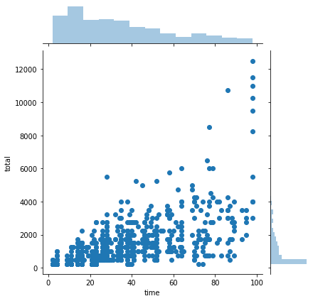

```python
#collapse-show
sns.jointplot(x='time', y='total', data=df)
```

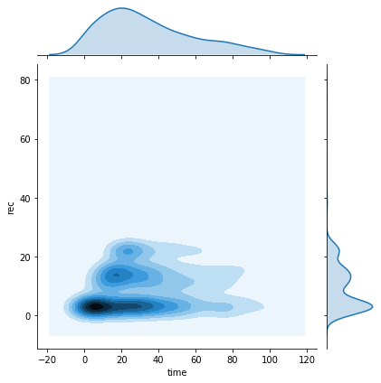

```python
#collapse-show
sns.jointplot(x='time', y='rec', data=df, kind='kde')
```

### Pairplot

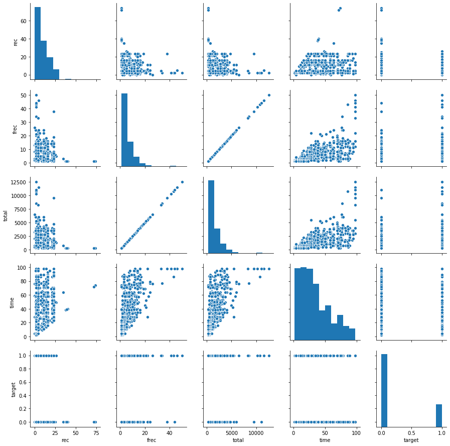

```python
#collapse-hide
sns.pairplot(df)
```

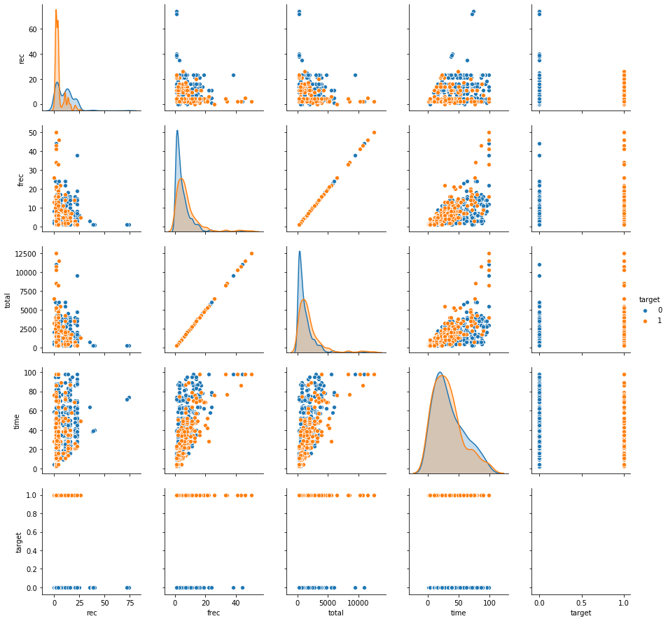

```python
#collapse-hide
sns.pairplot(df, hue='target')
```

### Feature Eng

```python
#collapse-show
df['time_frec'] = df.time / df.frec
df['time_rec'] = df.time - df.rec
df['total_time'] = df.total / df.time
df.sample(5)
```

|  | rec | frec | total | time | target | time_frec | time_rec | total_time |
| --- | --- | --- | --- | --- | --- | --- | --- | --- |
| 7 | 1 | 12 | 3000 | 35 | 0 | 2.916667 | 34 | 85.714286 |
| 37 | 4 | 6 | 1500 | 16 | 1 | 2.666667 | 12 | 93.750000 |
| 242 | 4 | 3 | 750 | 25 | 1 | 8.333333 | 21 | 30.000000 |
| 49 | 2 | 2 | 500 | 2 | 0 | 1.000000 | 0 | 250.000000 |
| 469 | 11 | 2 | 500 | 70 | 0 | 35.000000 | 59 | 7.142857 |

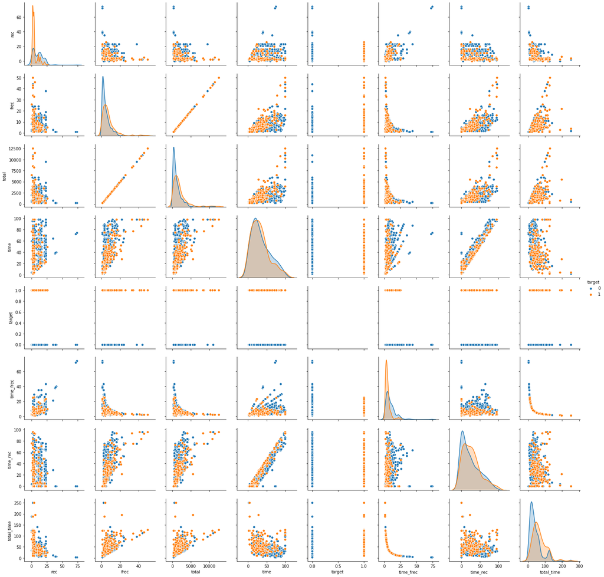

```python
#collapse-hide
sns.pairplot(df, hue='target')
```

## Save DataFrame to picckle

```python
df.to_pickle('data/dados.pkl')
```

## Modelagem

```python
import pickle

pickle_in = open("data/dados.pkl","rb")
data = pickle.load(pickle_in)
```

```python
x = data[['rec', 'frec', 'total', 'time', 'time_frec', 'time_rec','total_time']]

y = data.target
```

```python
# Split

from sklearn.model_selection import train_test_split

X_train, X_valid, y_train, y_valid = train_test_split(x, y, test_size=0.33, random_state=42)
```

### GaussianNB - acc 70%

```python
#collapse-show
from sklearn import datasets
from sklearn import metrics
from sklearn.naive_bayes import GaussianNB

# Classificador
clf = GaussianNB()

# Modelo
modelo = clf.fit(X_train, y_train)
print(modelo)

# Previsões
previsto = modelo.predict(X_valid)

# Sumário
print(metrics.classification_report(y_valid, previsto))
print(metrics.confusion_matrix(y_valid, previsto))
```

```
GaussianNB(priors=None, var_smoothing=1e-09)
              precision    recall  f1-score   support

           0       0.77      0.85      0.81       181
           1       0.43      0.30      0.35        66

    accuracy                           0.70       247
   macro avg       0.60      0.58      0.58       247
weighted avg       0.68      0.70      0.69       247

[[154  27]
 [ 46  20]]
```

### Logistic Regression - acc 74%

```python
#collapse-show
from sklearn.linear_model import LogisticRegressionCV
from sklearn import metrics


#classifier
clf = LogisticRegressionCV(cv=5, random_state=0).fit(X_train, y_train)
print(clf)

# Previsões
previsto = clf.predict(X_valid)

# Sumário
print(metrics.classification_report(y_valid, previsto))
print(metrics.confusion_matrix(y_valid, previsto))
```

```
LogisticRegressionCV(Cs=10, class_weight=None, cv=5, dual=False,
                     fit_intercept=True, intercept_scaling=1.0, l1_ratios=None,
                     max_iter=100, multi_class='warn', n_jobs=None,
                     penalty='l2', random_state=0, refit=True, scoring=None,
                     solver='lbfgs', tol=0.0001, verbose=0)
              precision    recall  f1-score   support

           0       0.75      0.98      0.85       181
           1       0.60      0.09      0.16        66

    accuracy                           0.74       247
   macro avg       0.67      0.53      0.50       247
weighted avg       0.71      0.74      0.66       247

[[177   4]
 [ 60   6]]
```

### SVM - acc 73%

```python
#collapse-show
from sklearn import svm
from sklearn import metrics


#classifier
clf = svm.SVC().fit(X_train, y_train)
print(clf)

# Previsões
previsto = clf.predict(X_valid)

# Sumário
print(metrics.classification_report(y_valid, previsto))
print(metrics.confusion_matrix(y_valid, previsto))
```

```
SVC(C=1.0, cache_size=200, class_weight=None, coef0=0.0,
    decision_function_shape='ovr', degree=3, gamma='auto_deprecated',
    kernel='rbf', max_iter=-1, probability=False, random_state=None,
    shrinking=True, tol=0.001, verbose=False)
              precision    recall  f1-score   support

           0       0.74      0.97      0.84       181
           1       0.50      0.09      0.15        66

    accuracy                           0.73       247
   macro avg       0.62      0.53      0.50       247
weighted avg       0.68      0.73      0.66       247

[[175   6]
 [ 60   6]]
```

### Tree - acc 67%

```python
#collapse-show
from sklearn import tree

#classifier
clf = tree.DecisionTreeClassifier().fit(X_train, y_train)
print(clf)

# Previsões
previsto = clf.predict(X_valid)

# Sumário
print(metrics.classification_report(y_valid, previsto))
print(metrics.confusion_matrix(y_valid, previsto))
```

```
DecisionTreeClassifier(class_weight=None, criterion='gini', max_depth=None,
                       max_features=None, max_leaf_nodes=None,
                       min_impurity_decrease=0.0, min_impurity_split=None,
                       min_samples_leaf=1, min_samples_split=2,
                       min_weight_fraction_leaf=0.0, presort=False,
                       random_state=None, splitter='best')
              precision    recall  f1-score   support

           0       0.76      0.81      0.78       181
           1       0.36      0.29      0.32        66

    accuracy                           0.67       247
   macro avg       0.56      0.55      0.55       247
weighted avg       0.65      0.67      0.66       247

[[147  34]
 [ 47  19]]
```